# Supremum Augmented Dickey Fuller Test - SADF- Pytorch 2 GPU

```python
import os
home = os.environ['USERPROFILE']
os.chdir(os.path.join(home, r'Projects\stocks\mt5\python'))
```

```python
import util
import pandas as pd
import datetime
import numpy as np
import importlib
import glob
from matplotlib import pylab as plt
from statsmodels.tsa.stattools import adfuller # stationarity test
import talib as ta
from numba import jit

from sklearn.ensemble import ExtraTreesClassifier
import pickle
from sklearn.metrics import accuracy_score, recall_score, confusion_matrix, classification_report
import sys
from scipy.stats import entropy
```

```python
os.chdir(os.path.join(home, r'Projects\stocks\algos'))
```

```python
import util
import torch as th
```

### Idea go to GPU Supremum Dickey Fuller test

- Cannot thing of one way to make it faster
- Did not make it better (in fact performance is worse using pytorch equal adf size batch)
  - Since there thousand of matrixes but they are small and with different sizes
  - GPU bootleneck is memory i/o making it slower than CPU code GTX 1060 6GB

### Dickey Fuller Test

$$ \Delta y_t = a_0 + a_1t + \delta y_{t-1} + \epsilon_t $$

- $ \epsilon_t $ error term (will be minimized)
- $\Delta$ first difference operator
- $a_0$ drift term
- $a_1$ time trend or deterministic term

for example for $y_t$ in {0, 1, 2 ... 3} the overdetermined system

$$ y_0 = a_0 + a_1 0 + \delta 0 $$$$ y_1-y_0 = a_0 + a_1 1 + \delta y_{0} $$$$ y_2-y_1 = a_0 + a_1 2 + \delta y_{1} $$$$ y_3-y_2 = a_0 + a_1 3 + \delta y_{2} $$

### Augmented Dickey Fuller Test

replacing $a_0=\alpha$, $a1=\beta$ and $\delta=\gamma$ [Wikipedia convention](https://en.wikipedia.org/wiki/Augmented_Dickey%E2%80%93Fuller_test) .

$$ \Delta y_t = \alpha + \beta t + \gamma y_{t-1} + \delta_1 \Delta y_{t-1} + ... + \delta_{p-1} \Delta y_{t-p+1} + \epsilon_t $$

- $ \epsilon_t $ error term (will be minimized)
- $\Delta$ first difference operator
- $\alpha$ drift term
- $\beta$ time trend or deterministic term
- $p$ lag order must be choosen, using for example the Akaike and Schwartz (Bayesian) information criteria.

for example for $y_t$ in {0, 1, 2 ... 8}, N=9 and p=2. the overdetermined system is:

$$ \Delta y_3 = \alpha + \beta 3 + \gamma y_{2} + \delta_1 \Delta y_2 + \delta_2 \Delta y_1 $$$$ \Delta y_4 = \alpha + \beta 4 + \gamma y_{3} + \delta_1 \Delta y_3 + \delta_2 \Delta y_2 $$$$ \Delta y_5 = \alpha + \beta 5 + \gamma y_{4} + \delta_1 \Delta y_4 + \delta_2 \Delta y_3 $$$$ \Delta y_6 = \alpha + \beta 6 + \gamma y_{5} + \delta_1 \Delta y_5 + \delta_2 \Delta y_4 $$$$ \Delta y_7 = \alpha + \beta 7 + \gamma y_{6} + \delta_1 \Delta y_6 + \delta_2 \Delta y_5 $$$$ \Delta y_8 = \alpha + \beta 8 + \gamma y_{7} + \delta_1 \Delta y_7 + \delta_2 \Delta y_6 $$

- General case with data points $y_t$ in {0, 1, 2 ... **N**} and p=p.
- Variables are $\alpha$, $\beta$, $\gamma$ 3 plus p $\delta$'s, total is 3+p.
- **N** must be >= 3+p otherwise cannot apply ordinary least squares

$$ \begin{pmatrix} 1 & p+1 & y_{p} & \Delta y_{p} & \Delta y_{p-1}& \cdots & \Delta y_{1} \\ 1 & p+2 & y_{p+1} & \Delta y_{p+1} & \Delta y_{p} & \cdots & \Delta y_{2} \\ 1 & p+3 & y_{p+2} & \Delta y_{p+2} & \Delta y_{p+1}& \cdots & \Delta y_{3} \\ \vdots & \vdots & \vdots & \vdots & \vdots & \ddots & \vdots \\ 1 & N-1 & y_{N-2} & \Delta y_{N-2} & \Delta y_{N-3}& \cdots & \Delta y_{N-p-1} \\ \end{pmatrix} \begin{pmatrix} \alpha \\ \beta \\ \gamma \\ \delta_1 \\ \delta_2 \\ \vdots \\ \delta_p \\ \end{pmatrix} = \begin{pmatrix} \Delta y_{p+1}\\ \Delta y_{p+2}\\ \Delta y_{p+3}\\ \vdots \\ \Delta y_{N-1}\\ \end{pmatrix} $$

$$ \mathbf{X}_{N-p-1,3+p} \cdot \mathbf{\beta}_{3+p} = \Delta y_{N-p-1} $$

that is a overdermined last squares problem, using $z = \Delta y$:

$$ \mathbf{X} \cdot \mathbf{\beta} = z $$

The last squares solution is, :

$$ \mathbf{\hat{\beta}} = \left(\mathbf{X}^T \mathbf{X}\right)^{-1} \mathbf{X}^T z $$

The error

$$ \mathbf{\hat{\epsilon}} = z - \mathbf{X} \mathbf{\hat{\beta}}$$

The reduced chi-squared statistic:

$$ s^2 = \frac{\mathbf{\hat{\epsilon}}^T \mathbf{\hat{\epsilon}}}{N-p-1-(p+3)} $$

If the strict exogeneity does not hold (as is the case with many time series models, where exogeneity is assumed only with respect to the past shocks but not the future ones), then these estimators will be biased in finite samples. The estimated standard error of each coeficient $\mathbf{\hat{\beta}}_j$ is

$$ \hat{\sigma}_j = \hat{s.e.}\left(\mathbf{\hat{\beta}}_j \right) = \sqrt{s^2 \left(\mathbf{X}^T \mathbf{X}\right)^{-1}_{jj}} $$

For the specific case of $\mathbf{\hat{\beta}}_3$ ~ $\gamma$

$$ \hat{\sigma}_3 = \hat{s.e.}\left(\mathbf{\hat{\gamma}} \right) = \sqrt{s^2 \left(\mathbf{X}^T \mathbf{X}\right)^{-1}_{33}} $$

The the test statistic for $\mathbf{\hat{\gamma}}$ is

$$ t = \frac{\mathbf{\hat{\gamma}}}{\hat{\sigma}_3} $$

### Exact Solution for $ADF$ or batch size $ADF's$ (equal size)

- Implemented in `pytorch_adf` fully test against `statsmodel`

### Aproximated Solution for $SADF_t$ - batch size $ADF's$ (different sizes)

- for a $SADF_t$ $t$ point
- Start with matrix of the OLS of backward window of maximum length call it $X$
- For each $ADF$ required smaller than the previous zero the number of corresponding lines on $X$
- Implemented on `pytorch_sadft` with numerical errors

### Numerical errors of aproximation for calculating thousands of ADF's at once on GPU/CPU

- Aproximations is : zeroing first i lines of $X$ when doing $(X^T \cdot X)^{-1}$ for doing each smaller $ADF$ in $SADF_t$
  - using LU decomposition `torch.inverse`
- That's Greatly reduced by using `cholesky_inverse`| `cholesky_solve` for symmetric positive definite matrixes $X^T \cdot X$ case
- other possibilities to test (don't know if they would be usefull for something)
  - `torch.qr` QR factorization where Q is orthogonal and R upper triangular
    - very commom for OLS solution
  - `torch.lstsq` computes the solution to the least squares problem

```python
os.chdir(os.path.join(home, r'Projects\stocks\prototypes'))
```

```python
pwd
```

```
'D:\\Users\\andre.ferreira\\Projects\\stocks\\prototypes'
```

The Gramian Matrix $X^T\cdot X$

Considering $X_1, X_2 \cdots X_{p} $ colum vectors of Matrix $X$ the Gramian Matrix of $X$ is defined as the matrix of every dot product of these vectors.

$G_{ij} = X_i\cdot X_j $ Eistein notation

[figure not shown]

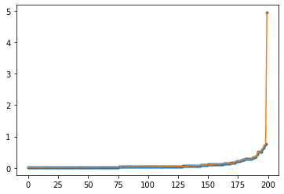

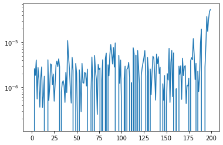

```python
x0 = 250
p = 50
X = th.rand(x0, p, dtype=th.float32)
errors = []

for i in range(x0-p):
    Xs = X[i:]
    #a = th.inverse(th.matmul(Xs.transpose(0, -1).view(1, 30, x0-i), Xs.view(1, x0-i, 30)).view(30, -1)).sum()
    a = th.matmul(Xs.transpose(0, -1).view(1, p, x0-i), Xs.view(1, x0-i, p)).view(p, -1)
    L = th.cholesky(a, False)
    a = th.cholesky_solve(th.eye(p), L, False).sum()
    Xs = X.clone()
    Xs[:i] = 0
    #b = th.inverse(th.matmul(Xs.transpose(0, -1).view(1, 30, x0), Xs.view(1, x0, 30)).view(30, -1)).sum()
    b = th.matmul(Xs.transpose(0, -1).view(1, p, x0), Xs.view(1, x0, p)).view(p, -1)
    L = th.cholesky(b, False)
    b = th.cholesky_solve(th.eye(p), L, False).sum()
    errors.append([a.item(), b.item()])

errors = np.array(errors)

plt.plot(errors[:, 0], '.')
plt.plot(errors[:, 1])
plt.figure()
plt.plot(np.abs((errors[:, 1]-errors[:, 0])/(errors[:, 1])))
plt.yscale('log')
```

```python
os.chdir(os.path.join(home, r'Projects\stocks\data'))
```

```python
ibov = pd.read_csv('BVSP.csv', delimiter=',',
                 na_values=['null', '0'])
```

```python
ibov = ibov[-2000:]
```

```python
ibov = ibov[['Close', 'Date']]
```

```python
ibov = ibov.fillna(method='ffill')
```

```python
data = ibov.Close.values
```

```python
ibov.set_index(pd.DatetimeIndex(ibov.Date), drop=True, inplace=True)
```

```python
ibov.head()
```

| Date | Close | Date |
| --- | --- | --- |
| 2011-12-16 | 56097.0 | 2011-12-16 |
| 2011-12-19 | 55298.0 | 2011-12-19 |
| 2011-12-20 | 56865.0 | 2011-12-20 |
| 2011-12-21 | 56653.0 | 2011-12-21 |
| 2011-12-22 | 57348.0 | 2011-12-22 |

```python
size = len(data) # number of bars example
minw = 21*4 # mininum window size for serial correlation analyses
maxw = 21*8 # maximum .... 3 months
print(maxw-minw, size) # number of calculations per t value
```

```
84 2000
```

### Controlling criteria for reducing error

min window must be at least above $ (2*p+4) $ 50% to make relative error bellow 2% (compared to `statsmodel`)

```python
p=35
minw = int((2*p+4)*1.5)
maxw = maxw
2*p+4, minw, maxw
```

```
(74, 111, 168)
```

```python
t = maxw+700
```

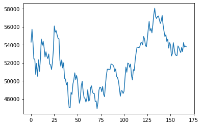

```python
plt.plot(data[t-maxw:t])
```

- maybe due matrix multiplication
- maybe due cholesky manipulations

```python
indata = data[t-maxw:t]
```

```python
ndata = -0.5 + ((np.max(indata) - indata)/np.abs(np.max(indata)-np.min(indata)))
```

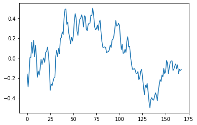

```python
plt.plot(ndata)
```

```python
os.chdir(os.path.join(home, r'Projects\stocks\mt5\python'))
import urt
import importlib
importlib.reload(urt)

adfs = []
for i in range(maxw-minw):
    adfs.append(urt.torch_adf(ndata[i:].astype(np.float32), p));
```

```python
adfs = np.array(adfs, dtype=np.float32)
```

```python
adfs.shape
```

```
(57, 2)
```

```python
adfst = urt.torch_sadft(ndata.astype(np.float32), maxw, minw, p=p, verbose=True)
```

```python
maxw-minw
```

```
57
```

### $ADFs$ precise vs approximated $ADFs$ $SADF_t$

#### Gramian Matrix Inverse Sum

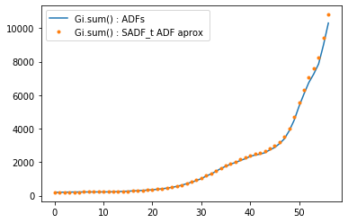

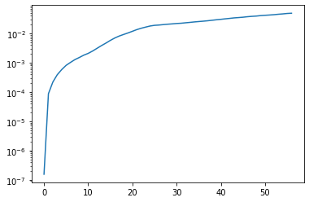

```python
plt.plot(adfs[:, 1], label='Gi.sum() : ADFs ')
plt.plot(adfst[1], '.', label='Gi.sum() : SADF_t ADF aprox ')
plt.legend()
plt.figure()
plt.plot(abs(adfst[1]-adfs[:, 1])/adfs[:, 1])
plt.yscale('log')
```

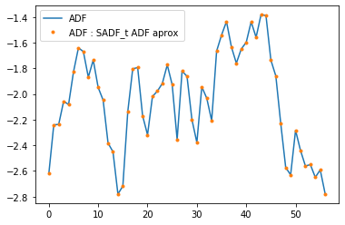

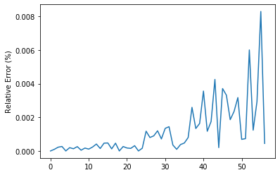

```python
plt.plot(adfs[:, 0], label='ADF')
plt.plot(adfst[0], '.', label='ADF : SADF_t ADF aprox ')
plt.legend()
plt.figure()
plt.plot(100*abs((adfst[0]-adfs[:,0])/(adfs[:,0])))
plt.ylabel('Relative Error (%)')
```

```python
adfst[0][::-1][:15]
```

```
array([-2.778425 , -2.5913682, -2.649118 , -2.550482 , -2.5608063,
       -2.4399235, -2.282814 , -2.6303449, -2.5723634, -2.2306936,
       -1.8596154, -1.73592  , -1.3878464, -1.3822671, -1.5583065],
      dtype=float32)
```

```python
adfs[:, 0][::-1][:15]
```

```
array([-2.7784126, -2.5911534, -2.6491957, -2.5504506, -2.56096  ,
       -2.4399414, -2.2828298, -2.6302614, -2.5724237, -2.230652 ,
       -1.8595538, -1.7359843, -1.3878436, -1.3822083, -1.5582792],
      dtype=float32)
```

### Min window `minw` too small problems

- OLS matrix $X^T\cdot X$ can become bad conditioned - (Cholesky will fail!)
  - if data is too similar on the previous times (lines will be almost linear dependent!)
- OLS number of lines (data size) too close to number of parameters being estimated
  - test statistics controlled by 2*p+4

### The less data (smaller `minw`) you use the more probable that's going to happen

```python
ndata = -0.5 + ((np.max(data) - data)/np.abs(np.max(data)-np.min(data)))
```

```python
p, minw, maxw
```

```
(35, 111, 168)
```

```python
%%time
sadf = urt.torch_sadf(ndata, maxw, minw, p=p, gpumem_GB=1., verbose=True)
```

```
35 2000
1964 1964 35 2000 torch.Size([1964, 38])
1964 1964 35 2000 torch.Size([1964, 38])
adfs_count  57
sadft_GB  0.0010651051998138428
batch_size  938
nsadft  1832
nbatchs  1
lst_batch_size  894
[################################################################################] 1/1
Wall time: 15.3 s
```

### statsmodels SADF

```python
stsadf = []
adfs = []
for t in util.progressbar(range(maxw, size)):
    adfs = []
    for i in range(maxw-minw): # expanding going back samples for calculations are getting smaller
        adfs.append(adfuller(ndata[t-maxw:t][i:].astype(np.float32), p, 'ct', autolag=None)[0])
    stsadf.append(np.max(adfs))
```

```
[################################################################################] 1832/1832
```

### Relative Error acceptable?

`Statsmodel` make calculations using **double** agains torch using **float**

```python
sadf=np.array(sadf)
stsadf=np.array(stsadf)
```

[figure not shown]

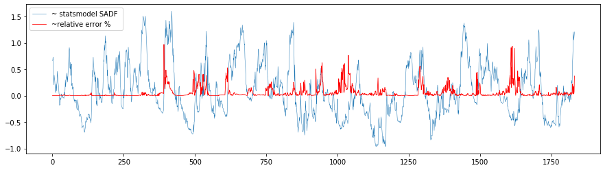

```python
plt.figure(figsize=(15,4))
plt.plot(sadf, label='statsmodel SADF (double)')
plt.plot(stsadf, 'r--', lw=0.5, label='torch SADF (float)')
plt.legend()
plt.figure(figsize=(15,4))
plt.plot(0.65+stsadf*0.5, label='~ statsmodel SADF ', lw=0.5)
plt.plot(100*np.abs(np.array(sadf+10)-(np.array(stsadf+10)))/(np.abs(stsadf+10)), 'r', lw=0.8, label='~relative error %')
plt.legend()
```

## You should ignore bellow

### Aditional tests with random data

### Numerical errors of aproximation for calculating thousands of ADF's at once on GPU/CPU

- Aproximations is : zeroing first i lines of $X$ when doing $(X^T \cdot X)^{-1}$ for doing each smaller $ADF$ in $SADF_t$
  - using LU decomposition `torch.inverse`
- That's Greatly reduced by using `cholesky_inverse`| `cholesky_solve` for symmetric positive definite matrixes $X^T \cdot X$ case

```python
indata = np.random.rand(3000)*90000
p=35
dev=th.device('cpu')
maxw=500
minw=90
print(2*p+4)
```

```
74
```

```python
np.min(indata), np.max(indata)
```

```
(55.373934996467696, 89996.89914505758)
```

```python
th.set_grad_enabled(False)
n = indata.size
nobs = n-p-1 # data used for regression
X = th.zeros((n-p-1, 3+p), device=dev, dtype=th.float32)
y = th.tensor(indata, device=dev, dtype=th.float32)

diffilter = th.tensor([-1., 1.], device=dev, dtype=th.float32).view(1, 1, 2)
dy = th.conv1d(y.view(1, 1, -1), diffilter).view(-1)
z = dy[p:].clone()
# X matrix
X[:, 0] = 1 # drift
X[:, 1] = th.arange(p+1, n) # deterministic trend
X[:, 2] = y[p:-1]# regression data (nobs)
# fill in columns, max lagged serial correlations
for i in range(1, p+1):
    X[:, 2+i] = dy[p-i:-i]
# sadf loop until minw, every matrix is smaller than the previous
# zeroing i lines, observations are becomming less also
batch_size = maxw-minw
Xb = X.repeat(batch_size, 1).view(batch_size, X.shape[0], X.shape[1])
zb = z.repeat(batch_size, 1).view(batch_size, X.shape[0], 1) # additonal dim for matrix*vector mult.
nobsi = th.zeros(batch_size, dtype=th.float32)

ststats = np.zeros(batch_size)
#zeromask = th.ones(batch_size, nobs, dtype=th.float32)
for i in range(batch_size): # each is smaller than previous
    Xb[i, :i, :] = 0
    zb[i, :i] = 0
    nobsi[i] = n-(float(i)+2*p+4)
    sXb = X[i:, :]
    szb = z[i:]
    sXt = sXb.t()
    sL = th.cholesky(th.matmul(sXt, sXb))
    sGi = th.cholesky_solve(th.eye(p+3), sL) # ( X^T . X ) ^-1
    # how to ignore i first lines  of bmm(Xt, zbt)
    sXtz= th.matmul(sXt, szb)
    sBhat = th.matmul(sGi, sXtz)
    szhat = th.matmul(sXb, sBhat) #*zeromask.unsqueeze(-1)  # estimated z
    # need to zeroing zhat entries
    # each lines must b
    ser = (szb - szhat) #*zeromask.unsqueeze(-1) # zeromask # hadamart product
    sBhat = sBhat.squeeze()
    ss2 = th.matmul(ser.t(), ser).view(-1)/nobsi[i]
    ststats[i] = sBhat[2]/th.sqrt(ss2*sGi[2,2])

Xt = Xb.transpose(dim0=1, dim1=-1)
L = th.cholesky(th.bmm(Xt, Xb))
Gi = th.cholesky_solve(th.eye(p+3), L) # ( X^T . X ) ^-1
# how to ignore i first lines  of bmm(Xt, zbt)
Xtz= th.bmm(Xt, zb)
Bhat = th.bmm(Gi, Xtz)
zhat = th.bmm(Xb, Bhat) #*zeromask.unsqueeze(-1)  # estimated z
# need to zeroing zhat entries
# each lines must b
er = (zb - zhat) #*zeromask.unsqueeze(-1) # zeromask # hadamart product
Bhat = Bhat.squeeze()
s2 = th.matmul(er.transpose(dim0=1, dim1=-1), er).view(-1)/nobsi
tstats = Bhat[:, 2]/th.sqrt(s2*Gi[:, 2,2])

tstats = tstats.data.numpy()
#return tstats.data.numpy(), Gi.sum(1).sum(1).data.numpy()
```

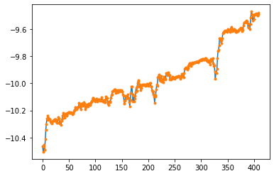

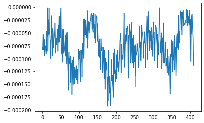

```python
plt.plot(tstats)
plt.plot(ststats,'.')
plt.figure()
plt.plot(np.abs(tstats-ststats)/(ststats+1))
```